# Populations and Samples

Author

Global Health and Infectious Diseases Group - KCCR-KNUST, Ghana for ISARIC

## Populations and Samples

In clinical research, understanding the concepts of populations and samples is crucial. A **population** refers to the entire group of individuals or instances about whom we hope to learn. A **sample** is a subset of the population that is actually observed or analyzed. For example, if we are studying the effects of a new drug on patients with a specific condition, the population would include all patients with that condition, while the sample would consist of those patients who participate in the study.

For obvious reasons, we cannot study the entire population, so we rely on samples to make inferences about the population. Reasons why we use samples include:

- **Feasibility**: Studying the entire population may be impractical or impossible due to time, cost, or logistical constraints.
- **Efficiency**: Samples allow researchers to obtain results more quickly and with fewer resources.
- **Ethical considerations**: In clinical research, it may not be ethical to expose the entire population to a new treatment or intervention without prior evidence of its safety and efficacy.
- **Cost**: Conducting research on a sample is often more cost-effective than studying the entire population, as it requires fewer resources and less time. Realistically too, you may not have access to the entire population, making it necessary to work with a sample.

When selecting a sample, it is important to ensure that it is representative of the population. This means that the characteristics of the sample should closely match those of the population, allowing for valid generalizations. Various sampling methods can be employed to achieve this, including random, stratified, and cluster sampling.

In this chapter, we focus on populations and samples, representativeness in clinical research, and various sampling methods with their implications for study design and data analysis. We’ll use **tidyverse**, a collection of R packages for data manipulation and visualization, including ggplot2, dplyr, tidyr, readr, purrr, and tibble. These packages provide a consistent, user-friendly interface for data work.

## Setting up the Environment

```r
if (!requireNamespace("tidyverse", quietly = TRUE)) {
  install.packages("tidyverse")
}
library(tidyverse, warn.conflicts = FALSE)
```

## Loading the Dataset

We use a synthetic dataset stored at a public URL. By storing the link as a variable, we make it easier to update or modify the data source in the future. The `read.csv()` function is a base R function that converts a CSV file into a data frame, which is R’s standard data structure for tabular data.

```r
link <- "https://raw.githubusercontent.com/EstebanGarciaG/Lectures/main/data/data_synth.csv"
df <- read.csv(link)
```

## Output Hidden

**Warning**

The `output: false` option prevents the output from displaying because the dataset is too wide for the console. Run this code interactively to inspect the first few rows. Press Ctrl+Enter (Windows/Linux) or Cmd+Enter (Mac) with the cursor at the end of the line.

```r
head(df)
```

## Exploring Your Dataset

The output above didn’t print nicely because the dataset is too wide for the console. Several functions help with this:

- **`View()`** — Opens data in a separate RStudio tab for scrolling (base R function)
- **`view()`** — Tidyverse equivalent with similar functionality
- **`glimpse()`** — Quick overview of structure and variable types, ideal for large datasets
- **`as_tibble()`** — Convert to tibble format for cleaner, more readable console output

Try any of these to explore the data more easily.

## Converting to Tibble Format

Tibbles are a modern take on R data frames that provide cleaner, more readable output, especially for wide datasets. The assignment operator `<-` assigns the converted tibble back to the variable `df`.

Table 1

```r
df <- as_tibble(df)
head(df)
```

```
# A tibble: 6 × 212
  subjid      inclu_disease    dates_onsetdate dates_admdate dates_enrolmentdate
  <chr>       <chr>            <chr>           <chr>         <chr>
1 00000-00001 "Avian influenz… 2025-03-23      2025-03-25    2025-03-25
2 00000-00002 ""               2025-01-25      2025-01-26    2025-01-26
3 00000-00003 ""               2025-01-14      2025-01-14    2025-01-14
4 00000-00004 ""               2025-03-06      2025-03-06    2025-03-06
5 00000-00005 ""               2025-01-13      2025-01-14    2025-01-14
6 00000-00006 ""               2025-03-26      2025-03-26    2025-03-26
# ℹ 207 more variables: demog_sex <chr>, demog_age <dbl>,
#   demog_age_units <chr>, demog_healthcare <chr>, comor_hypertensi <chr>,
#   comor_chrkidney <chr>, comor_chrkidney_stag <chr>,
#   comor_liverdisease <chr>, comor_liverdisease_type <chr>,
#   comor_obesity <chr>, comor_diabetes_yn <chr>, comor_smoking_yn <chr>,
#   vacci_influenza_yn <chr>, adsym_fever <chr>, adsym_headache <chr>,
#   daily_date <chr>, daily_date.1 <chr>, vital_highesttem_c <dbl>, …
```

```r
glimpse(df)
```

Some times, your particular focus will be on a variable, for that reason, you will process that variable to make it more usefule. **A variable is a column of a dataset in this sense**. To view the variables in the dataset, you can use the `colnames()` function, which returns a character vector containing the names of the variables (columns) in the dataset. This allows you to quickly identify the variables available for analysis and their corresponding names.

## Exploring Column Names

The `colnames()` function returns all variable names in the dataset. You can use the `view()` function (from tidyverse) to explore these names in a more readable format, particularly useful for wide datasets with many variables.

```r
cnames <- colnames(df)

cnames
```

## Focusing on Platelets

Our analysis focuses on the `labs_platelets_103ul` variable, so it’s important to examine it closely in the next steps.

## Summarizing the Key Variable

The `summary()` function provides quick descriptive statistics for the `labs_platelets_103ul` variable, including mean, median, quartiles, and range. This gives us a first look at the variable’s distribution and potential data quality issues.

```r
summary(df$labs_platelets_103ul)
```

```
   Min. 1st Qu.  Median    Mean 3rd Qu.    Max.     NAs
  0.855   1.926   2.440   2.524   3.029   6.552     274
```

## Understanding Functions

This is a great moment to review how functions work. A function is a **reusable** piece of code that performs a specific task. Instead of writing the same code repeatedly, a function lets you execute it once, then call it many times with different inputs. This makes your code more efficient, maintainable, and less prone to errors.

## Creating a Reusable Function

Functions are reusable pieces of code that perform specific tasks. This `sample_summary()` function computes key statistics (mean, SD, SE, N) for any variable. The `na.omit()` function removes missing values—critical because NAs can distort calculations. Standard error (SE = SD / √n) estimates the variability of the sample mean and is essential for confidence intervals and hypothesis tests.

```r
sample_summary <- function(x) {
  x <- na.omit(x)
  n <- length(x)
  mean_x <- mean(x)
  sd_x <- sd(x)
  se_x <- sd_x / sqrt(n)
  return(data.frame(
    Mean = round(mean_x, 1),
    SD = round(sd_x, 1),
    SE = round(se_x, 2),
    N = n
  ))
}
```

The standard error (SE) is calculated as the standard deviation (SD) divided by the square root of the sample size (n). This formula reflects how variability decreases as sample size increases, which is a fundamental concept in statistics.

$$SE = \frac{SD}{\sqrt{n}}$$

## Testing the Function

We test our `sample_summary()` function with a vector that contains a missing value (NA). This ensures the function correctly handles missing data by omitting it from calculations.

```r
vt <- c(1, 2, 3, 4, 5, NA)
sample_summary(vt)
```

```
  Mean  SD   SE N
1    3 1.6 0.71 5
```

## Observing NA Handling

**Warning**

Even though we passed 6 values to the function, it only used 5—because `na.omit()` removed the missing value (NA) from the calculations. This is critical to understand when working with real-world datasets: missing values are common and can distort analysis results if not handled properly. Our function ensures calculations are based only on available data.

```r
set.seed(123)
```

## Comparing Sampling Methods

This code applies four different sampling methods to the dataset. Each method has distinct advantages and limitations:

- **Random Sample**: Unbiased, each observation has equal probability
- **Systematic Sample**: Every nth observation selected (simple but may miss patterns)
- **Stratified Sample**: Samples from groups separately, ensuring representation of each group
- **Convenience Sample**: Uses readily available data (biased, may not represent population well)

```r
s_size <- 20
summary_pop <- sample_summary(df$labs_platelets_103ul)

samp_random <- sample_n(df, s_size)
summary_random <- sample_summary(samp_random$labs_platelets_103ul)

samp_systematic <- df[seq(1, s_size * 10, by = 10), ]
samp_systematic <- head(samp_systematic, s_size)
summary_systematic <- sample_summary(samp_systematic$labs_platelets_103ul)

samp_stratified <- df %>%
  group_by(demog_sex) %>%
  sample_n(s_size, replace = FALSE)
summary_stratified <- sample_summary(samp_stratified$labs_platelets_103ul)

samp_convenience <- head(df, s_size)
summary_convenience <- sample_summary(samp_convenience$labs_platelets_103ul)

results <- rbind(
  Populaton = summary_pop,
  Random = summary_random,
  Systematic = summary_systematic,
  Stratified = summary_stratified,
  Convenience = summary_convenience
)
```

## Interpreting the Sampling Results

**Warning**

Compare each sample mean to the population mean (2.5). Differences indicate sampling bias. Try adjusting `s_size` and rerunning—you’ll see how sample size affects accuracy. Note: larger samples don’t guarantee better representation if the sampling method itself is biased (e.g., convenience sampling).

Ethical consideration: In clinical research, smaller well-designed samples are preferable to larger ones that expose unnecessary risk to participants.

```r
results
```

```
            Mean  SD   SE    N
Populaton    2.5 0.8 0.03 1000
Random       2.6 0.6 0.16   14
Systematic   2.4 1.0 0.22   20
Stratified   2.5 1.1 0.20   30
Convenience  2.6 0.9 0.20   20
```

## Testing the Standard Error of Different Sample Sizes

Standard error decreases as sample size increases, but the relationship is not linear—it follows the formula SE = SD / √n. This section explores how SE varies across different sample sizes, illustrating the principle of diminishing returns: gains in precision become smaller as sample size grows.

```r
sample_sizes <- c(10, 20, 50, 100, 200, 500)

se_results <- data.frame(
  n = integer(),
  Mean = numeric(),
  SD = numeric(),
  SE = numeric()
)

for (n in sample_sizes) {
  samp <- sample(df$labs_platelets_103ul, n, replace = FALSE)
  stats <- sample_summary(samp)
  se_results <- rbind(
    se_results,
    data.frame(n = n, Mean = stats$Mean, SD = stats$SD, SE = stats$SE)
  )
}
```

## Results Table

As sample size increases, standard error decreases, reflecting increased precision in our estimates. However, notice the diminishing returns: the SE decrease from n=10 to n=20 is more substantial than from n=200 to n=500.

```r
se_results
```

```
    n Mean  SD   SE
1  10  2.5 0.8 0.27
2  20  2.6 0.8 0.23
3  50  2.5 0.9 0.14
4 100  2.5 0.8 0.08
5 200  2.5 0.7 0.06
6 500  2.6 0.8 0.04
```

## Key Insight: Diminishing Returns

**Warning**

The steep drop in standard error at small sample sizes levels off as n increases. This illustrates why researchers must balance precision needs against practical constraints (time, cost, ethical burden). In clinical research, a sample of n=50 may offer sufficient precision without exposing unnecessary participants to risk.

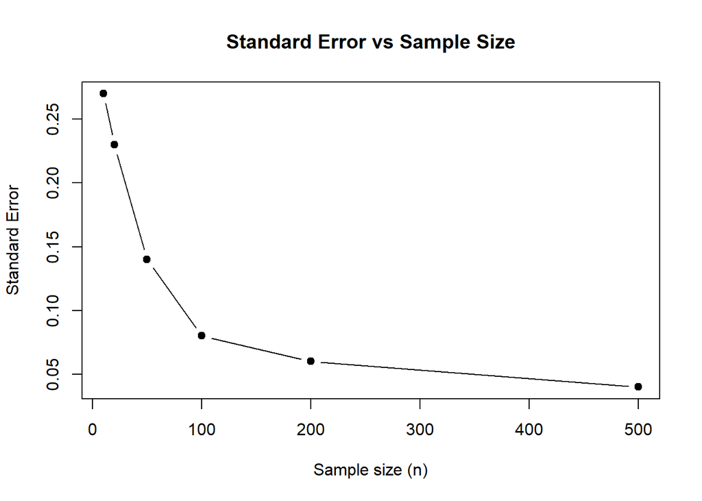

Figure 1: Standard Error vs Sample Size

```r
plot(
  se_results$n,
  se_results$SE,
  type = "b",
  pch = 19,
  xlab = "Sample size (n)",
  ylab = "Standard Error",
  main = "Standard Error vs Sample Size"
)
```